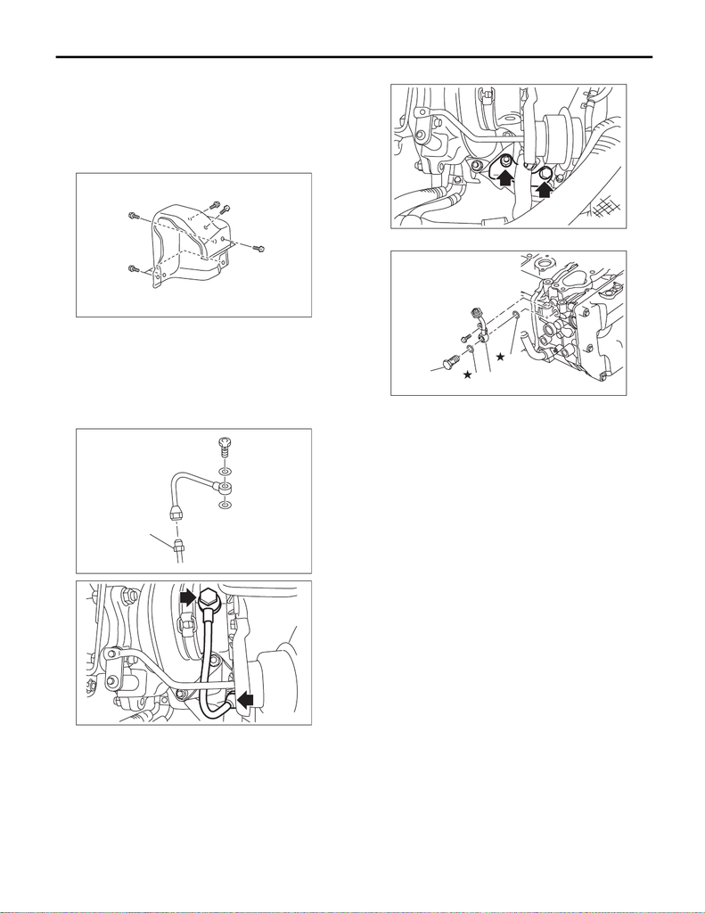

LU(STI)-24

Oil Pipe

LUBRICATION

8. Oil Pipe

A: REMOVAL

1) Disconnect the ground cable from battery.

2) Remove the intercooler. <Ref. to IN(STI)-13,

REMOVAL, Intercooler.>

3) Remove the turbocharger upper cover.

4) Remove the oil inlet pipe from the turbocharger.

CAUTION:

In order to prevent damaging the oil pipe on the

cylinder head side, fix the section (a) shown in

the figure when loosing the oil inlet pipe flare

nut, and avoid the part from rotating together

while loosening the nut.

5) Remove the turbocharger stay.

6) Remove the turbocharger oil pipe.

7) Drain engine coolant. <Ref. to CO(STI)-13,

DRAINING OF ENGINE COOLANT, REPLACE-

MENT, Engine Coolant.>

8) Remove the intake manifold. <Ref. to FU(STI)-

17, REMOVAL, Intake Manifold.>

9) Remove the secondary air pump. (Oil pipe LH

only) <Ref. to EC(STI)-53, REMOVAL, Secondary

Air Pump.>

LU-02694

LU-02719

(a)

LU-02692

(A) Union bolt without filter (without protrusion)

(B) Gasket

(C) Turbocharger oil pipe

LU-02691

LU-02696

(C)

(B)

(A)

(B)

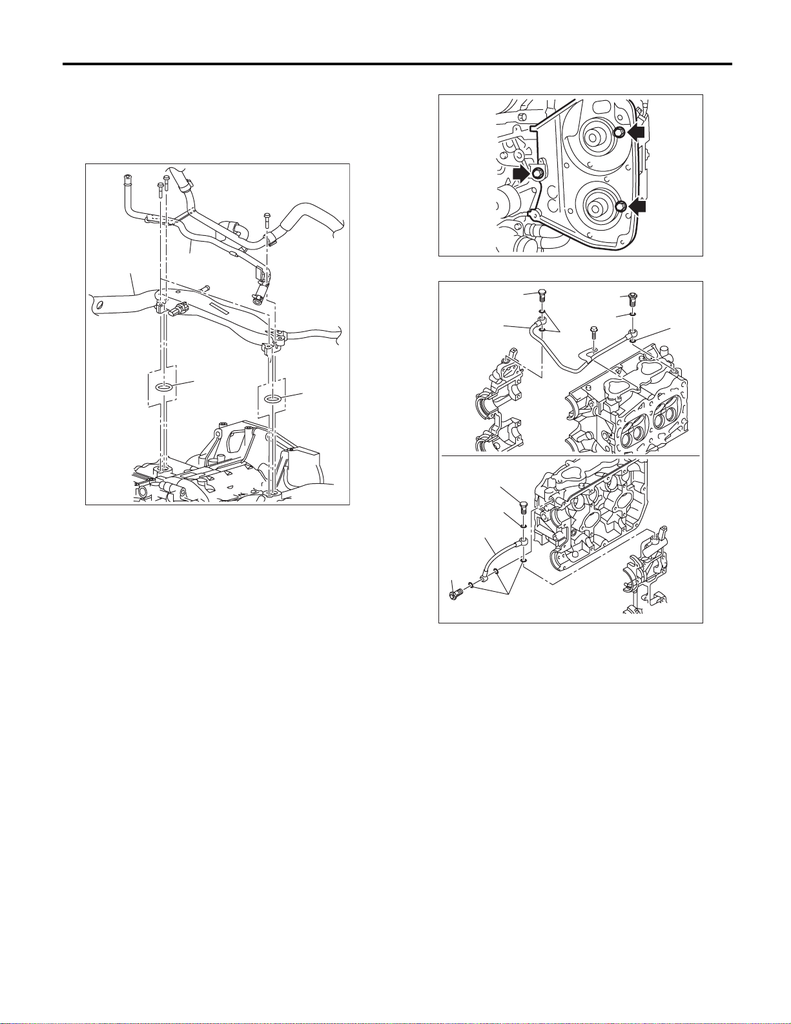

LU(STI)-25

Oil Pipe

LUBRICATION

10) Remove the blow-by pipe and water pipe as-

sembly. (Oil pipe RH only)

NOTE:

Do not remove the vacuum hose, radiator inlet

hose, and heater outlet hose.

11) Remove the radiator main fan and radiator sub

fan. <Ref. to CO(STI)-23, REMOVAL, Radiator

Main Fan and Fan Motor.> <Ref. to CO(STI)-25,

REMOVAL, Radiator Sub Fan and Fan Motor.>

12) Remove the V-belts. <Ref. to ME(STI)-41, RE-

MOVAL, V-belt.>

13) Remove the crank pulley. <Ref. to ME(STI)-48,

REMOVAL, Crank Pulley.>

14) Remove the timing belt cover. <Ref. to

ME(STI)-50, REMOVAL, Timing Belt Cover.>

15) Remove the timing belt. <Ref. to ME(STI)-51,

REMOVAL, Timing Belt.>

16) Remove the cam sprocket LH. <Ref. to

ME(STI)-60, REMOVAL, Cam Sprocket.>

17) Remove the timing belt cover No. 2 LH.

18) Remove the oil pipe.

(A) Water tank pipe ASSY

(B) Water pipe ASSY

(C) O-ring

(A)

(B)

(C)

(C)

LU-02722

(A) Union bolt with filter (with protrusion)

(B) Union bolt without filter (without protrusion)

(C) Oil pipe RH

(D) Oil pipe LH

(E) Gasket

CO-02908

ME-05030

(A)

(B)

(D)

(A)

(B)

(C)

(E)

(E)

(E)

(E)

(E)

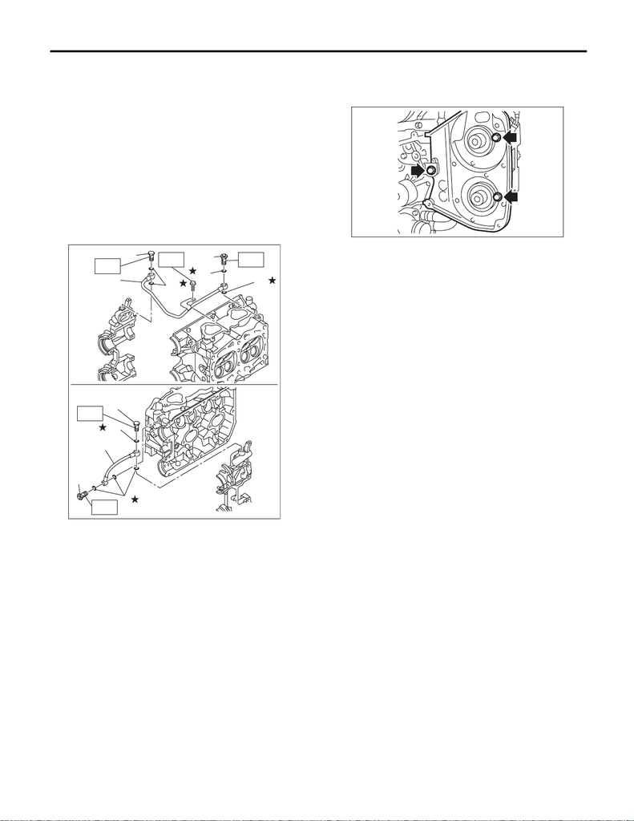

LU(STI)-26

Oil Pipe

LUBRICATION

B: INSTALLATION

1) Inspect the union bolt with filter. <Ref. to

LU(STI)-28, INSPECTING UNION BOLT WITH

FILTER, INSPECTION, Oil Pipe.>

2) Install the oil pipe.

NOTE:

• Be careful of the install location of the union bolt;

the location will differ depending on the presence of

filter.

• Use a new gasket.

Tightening torque:

T1: 6.4 N·m (0.7 kgf-m, 4.7 ft-lb)

T2: 29 N·m (3.0 kgf-m, 21.4 ft-lb)

3) Install the timing belt cover No. 2 LH.

Tightening torque:

5 N·m (0.5 kgf-m, 3.7 ft-lb)

4) Install the cam sprocket LH. <Ref. to ME(STI)-

60, INSTALLATION, Cam Sprocket.>

5) Install the timing belt. <Ref. to ME(STI)-54, TIM-

ING BELT, INSTALLATION, Timing Belt.>

6) Install the timing belt cover. <Ref. to ME(STI)-

50, INSTALLATION, Timing Belt Cover.>

7) Install the crank pulley. <Ref. to ME(STI)-48, IN-

STALLATION, Crank Pulley.>

8) Install the V-belts. <Ref. to ME(STI)-41, IN-

STALLATION, V-belt.>

9) Install the radiator main fan and the radiator sub

fan. <Ref. to CO(STI)-23, INSTALLATION, Radia-

tor Main Fan and Fan Motor.> <Ref. to CO(STI)-25,

INSTALLATION, Radiator Sub Fan and Fan Mo-

tor.>

(A) Union bolt with filter (with protrusion)

(B) Union bolt without filter (without protrusion)

(C) Oil pipe RH

(D) Oil pipe LH

(E) Gasket

LU-02710

(A)

(B)

(D)

(A)

(B)

(C)

(E)

(E)

(E)

(E)

(E)

T2

T1

T2

T2

T2

CO-02908

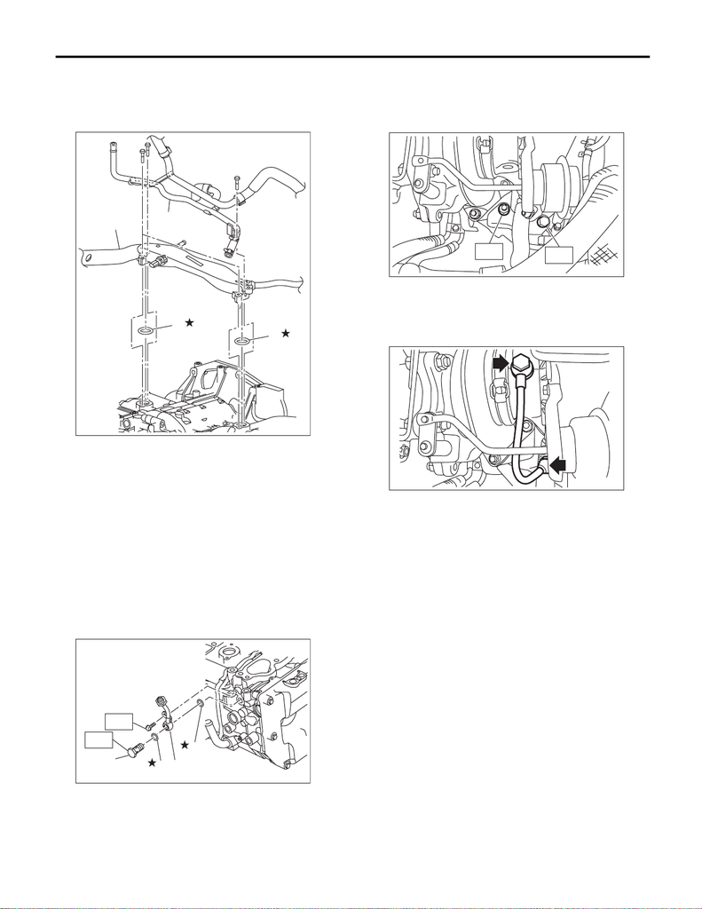

LU(STI)-27

Oil Pipe

LUBRICATION

10) Install the blow-by pipe and water pipe assem-

bly. (Oil pipe RH only)

Tightening torque:

6.4 N·m (0.7 kgf-m, 4.7 ft-lb)

11) Install the secondary air pump. (Oil pipe LH

only) <Ref. to EC(STI)-53, INSTALLATION, Sec-

ondary Air Pump.>

12) Install the intake manifold. <Ref. to FU(STI)-21,

INSTALLATION, Intake Manifold.>

13) Install the turbocharger oil pipe.

Tightening torque:

T1: 6.4 N·m (0.7 kgf-m, 4.7 ft-lb)

T2: 29 N·m (3.0 kgf-m, 21.4 ft-lb)

14) Install the turbocharger stay.

Tightening torque:

T1: 33 N·m (3.4 kgf-m, 24.3 ft-lb)

T2: 42.5 N·m (4.3 kgf-m, 31.3 ft-lb)

15) Temporarily tighten the bolts and flare nuts

which secure the oil inlet pipe to the turbocharger.

NOTE:

Use a new gasket.

(A) Water tank pipe ASSY

(B) Water pipe ASSY

(C) O-ring

(A) Union bolt without filter (without protrusion)

(B) Gasket

(C) Turbocharger oil pipe

(A)

(B)

(C)

(C)

LU-02721

LU-02698

(C)

(A)

(B)

(B)

T1

T2

LU-02713

T1

T2

LU-02692

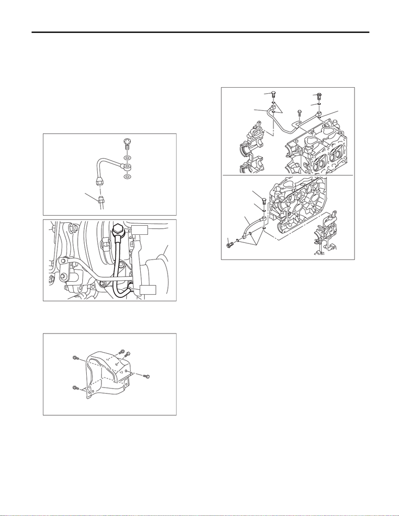

LU(STI)-28

Oil Pipe

LUBRICATION

16) Tighten the union bolts and flare nuts which se-

cure the oil inlet pipe to the turbocharger.

CAUTION:

In order to prevent damaging the oil pipe on the

cylinder head side, fix the section (a) shown in

the figure when tightening the oil inlet pipe flare

nut, and avoid the part from rotating together

while tightening the nut.

Tightening torque:

T1: 16 N·m (1.6 kgf-m, 11.8 ft-lb)

T2: 20 N·m (2.0 kgf-m, 14.8 ft-lb)

17) Attach the turbocharger upper cover.

Tightening torque:

7.5 N·m (0.8 kgf-m, 5.5 ft-lb)

18) Install the intercooler. <Ref. to IN(STI)-14, IN-

STALLATION, Intercooler.>

19) Connect the battery ground terminal.

20) Fill engine coolant. <Ref. to CO(STI)-13, FILL-

ING OF ENGINE COOLANT, REPLACEMENT,

Engine Coolant.>

C: INSPECTION

1. INSPECTING UNION BOLT WITH FILTER

Check the filter part of union bolt for clogging or

damage, and if defective, replace the union bolt

with filter with the new part.

2. OTHER INSPECTIONS

1) Check that the oil pipe and union bolt have no

deformation, cracks and other damages.

2) Check that there are no oil leaks or oil oozing

from the oil pipe attachment section.

LU-02719

(a)

T1

T2

LU-02700

LU-02694

(A) Union bolt with filter (with protrusion)

(B) Union bolt without filter (without protrusion)

(C) Oil pipe RH

(D) Oil pipe LH

(E) Gasket

ME-05030

(A)

(B)

(D)

(A)

(B)

(C)

(E)

(E)

(E)

(E)

(E)